# Project_1

Anonymous

11/9/2019

## Подготовка к работе

Устанавливаем необходимые пакеты:

Подгружаем установленные пакеты в текущую сессию R:

```r
library(ggplot2)
library(data.table)
library(dplyr)
```

Задаем путь к рабочей директории:

```r
path <- setwd("/home/gene/Orthonectida/Bioinf/1_semestr/Stat_R/R/data/mollusс_project/")
```

## **#1** Объединение файлов в одну таблицу

Данная функция объединяет все файлы с форматом .csv в одну таблицу

```r
merge_files_data <- function(path){
  file_list <- list.files(path, pattern = '*.csv')
  data <- data.frame()
  for(file in file_list){
    file = paste0(path,"/", file)
  data <- rbind(data, read.table(file, header = TRUE, stringsAsFactors = FALSE, dec = '.', sep=',' ))
  }
  return(data)
}
```

Запускаем данную функцию, с ранее созданной переменной **path**, сохраняя полученную таблицу в переменную **data**.

```r
data <- merge_files_data(path)
```

## **#2** Анализ собранных данных

Проверяем структуру полученной таблицы

```r
str(data)
```

```
## 'data.frame':    4177 obs. of  9 variables:
##  $ Rings                                 : chr  "18" "14" "8" "12" ...
##  $ Sex..1...male..2...female..3...uvenil.: chr  "2" "3" "1" "1" ...
##  $ Length                                : chr  "0.575" "0.385" "0.475" "0.665" ...
##  $ Diameter                              : num  0.45 0.305 0.37 0.525 0.12 0.16 0.565 0.43 0.175 0.3 ...
##  $ Height                                : num  0.17 0.095 0.125 0.18 0.075 0.05 0.2 0.15 0.055 0.115 ...
##  $ Whole_weight                          : num  1.048 0.252 0.649 1.429 0.117 ...
##  $ Shucked_weight                        : num  0.3775 0.0915 0.347 0.6715 0.0455 ...
##  $ Viscera_weight                        : num  0.171 0.055 0.136 0.29 0.029 ...
##  $ Shell_weight                          : num  0.385 0.09 0.142 0.4 0.0345 0.015 0.494 0.221 0.018 0.0935 ...
```

Меняем длинное имя 2ой переменной на более короткое, с которым будет удобно работать дальше.

```r
setnames(data, "Sex..1...male..2...female..3...uvenil.", "Sex")
```

Первые 3 переменные несмотря на свои числовые значения определились как **character**, а не **numeric**. Ищем некорректные значения при помощи функции **unique** показывающие только неповторяющиеся значения перменной.

```r
unique(data$Rings)
```

```
##  [1] "18"   "14"   "8"    "12"   "4"    "6"    "13"   "7"    "15"   "9"
## [11] "11"   "10"   "20"   "17"   "5"    "3"    "16"   "19"   "23"   "29"
## [21] "22"   "21"   "2"    "25"   "27"   "24"   "1"    "26"   "nine"
```

```r
unique(data$Sex)
```

```
## [1] "2"     "3"     "1"     NA      "three" "one"   "male"
```

```r
unique(data$Length)
```

```
##   [1] "0.575"                            "0.385"
##   [3] "0.475"                            "0.665"
##   [5] "0.28"                             "0.22"
##   [7] "0.72"                             "0.55"
##   [9] "0.235"                            "0.4"
##  [11] "0.255"                            "0.65"
##  [13] "0.395"                            "0.605"
##  [15] "0.485"                            "0.565"
##  [17] "0.61"                             "0.58"
##  [19] "0.54"                             "0.52"
##  [21] "0.56"                             "0.595"
##  [23] "0.43"                             "0.465"
##  [25] "0.57"                             "0.71"
##  [27] "0.75"                             "0.63"
##  [29] "0.655"                            "0.73"
```

[output cut: 53 more lines]

Меняем некорректно заполненные значения на числовые, спасаем все, что можно спасти.

```r
data$Rings[data$Rings == 'nine'] <- 9

data$Sex[data$Sex == 'one'] <- 1
data$Sex[data$Sex == 'male'] <- 1
data$Sex[data$Sex == 'three'] <- 3
```

Превращаем все наши переменные в **numeric** и проверяем все переменные на присутствие **NA**.

```r
data[1:3] <- apply(data[1:3],2, as.numeric)
apply(data, 2, function(x) any(is.na(x)))
```

```
##          Rings            Sex         Length       Diameter         Height
##          FALSE           TRUE           TRUE           TRUE           TRUE
##   Whole_weight Shucked_weight Viscera_weight   Shell_weight
##           TRUE           TRUE          FALSE           TRUE
```

Пропущенные значения встречающиеся в факторных переменных можно либо удалить либо заменить на моду. Первый вариант предпочтительней, поэтому удаляем строчку где **NA** присутствует в переменной **Sex** и затем делаем ее факторной. В числовых переменных можно либо удалить измерения содержащие NA или заменить NA на среднее по этой переменной. Мы проделаем второй вариант. После всех преобразований проверим еще раз остались ли в переменных **NA**.

```r
data <- data[!is.na(data$Sex),]

data$Sex <- factor(data$Sex,
         levels = c("1", "2", "3"),
          labels = c("male", "female", "juvenil"))

data[,-2] <- apply(data[,-2], 2, function(x){ ifelse(is.na(x),mean(x,na.rm = TRUE), x)})

apply(data, 2, function(x) any(is.na(x)))
```

```
##          Rings            Sex         Length       Diameter         Height
##          FALSE          FALSE          FALSE          FALSE          FALSE
##   Whole_weight Shucked_weight Viscera_weight   Shell_weight
##          FALSE          FALSE          FALSE          FALSE
```

## **#3** Среднее значение и стандартное отклонение переменной Length для моллюсков разного пола

Рассчитаем среднее значение и стандартное отклонение переменной Length для моллюсков разного пола и построим график.

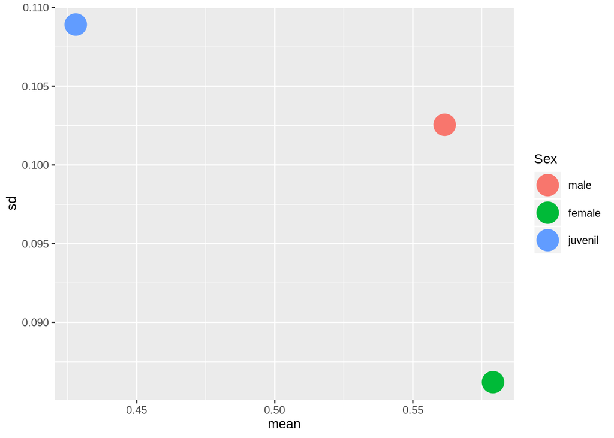

```r
stat_of_len <- data %>%
  group_by(Sex) %>%
  summarise(mean = mean(Length), sd = sd(Length))

ggplot(stat_of_len, aes(x = mean, y = sd , color = Sex)) +
  geom_point(size = 8)
```

## **#4** Процент моллюсков со значением переменной **Height** менее 0.165

Процент моллюсков со значением **Height** не превышающем 0.165 в данной выборке равен **71.2643678**

## **#5** Значение переменной **Length**, которое выше чем у **92%** всех наблюдений

```r
sorted_len <- sort(data$Length) # сортируем
result <- sorted_len[length(sorted_len)*0.92 + 1] # выводим элемент превышающий 92% всех наблюдений
```

Значение переменной **Length** выше чем у **92%** всех наблюдений равно **0.67**

## **#6** Стандартизация переменной **Length**

```r
Lenght_z_scores <- scale(data$Length)
```

## **#7** Сравнение между собой диаметр моллюсков с числом колец 5 и 15.

Для начала проверяем на нормальность распределения по значению **Diameter** у моллюсков с 5 и 15 кольцами.

```r
gr_data5 <- data %>%
  filter(Rings == 5) %>%
  select(Rings,Diameter)
shapiro.test(gr_data5$Diameter)
```

```
##
##  Shapiro-Wilk normality test
##
## data:  gr_data5$Diameter
## W = 0.98162, p-value = 0.1161
```

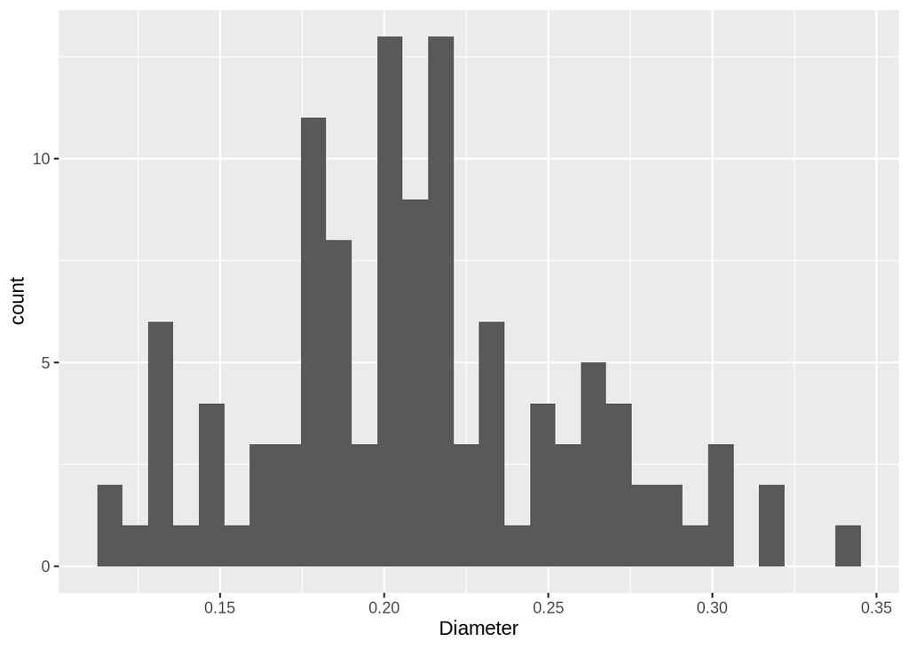

```r
ggplot(gr_data5, aes(Diameter)) +
  geom_histogram()
```

```r
gr_data15 <- data %>%
  filter(Rings == 15) %>%
  select(Rings,Diameter)
shapiro.test(gr_data15$Diameter)
```

```
##
##  Shapiro-Wilk normality test
##
## data:  gr_data15$Diameter
## W = 0.98227, p-value = 0.1836
```

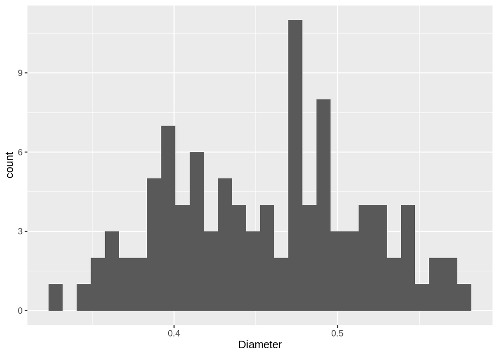

```r
ggplot(gr_data15, aes(Diameter)) +
  geom_histogram()
```

Шапиро-тест показал для переменной **Diameter** для моллюсков c 5 кольцами и для моллюсков с 15 кольцами, **p-value > 0.05**, поэтому принимаем нулевые гипотезы о том, что распределения нормальны.

Если распределения нормальны, можем применить t-test (не только в этом случае, но тут точно прям мамой клянусь можем). Нулевая гипотеза говорит о том, что наши распределения не различаются.

```r
result <- t.test(gr_data5,gr_data15)
```

В данном тесте получаем значение **p-value 8.120828110^{-19}** сильно меньше 0.05, что позволяет отклонить нулевую гипотезу, следовательно признак **Diameter** у улиток с 5 кольцами и у улиток с 15 кольцами доставерно различается.

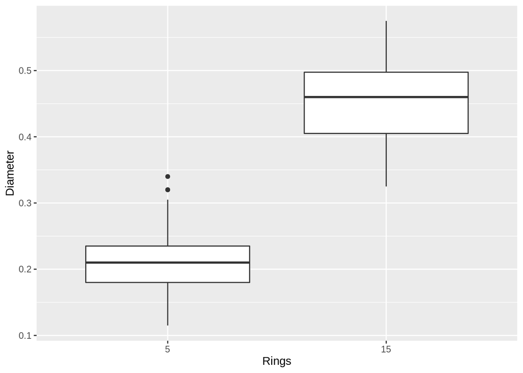

```r
gr_data <- data %>%
  filter(Rings == 5 | Rings == 15) %>%
  select(Rings,Diameter)

ggplot(gr_data, aes(as.factor(Rings), Diameter)) +
  geom_boxplot()+
  xlab('Rings')
```

## **#8** Взаимосвязь переменных Diametr и Whole_weight

Нарисуем график зависимости переменной **Diameter** от переменной **Whole_weight**

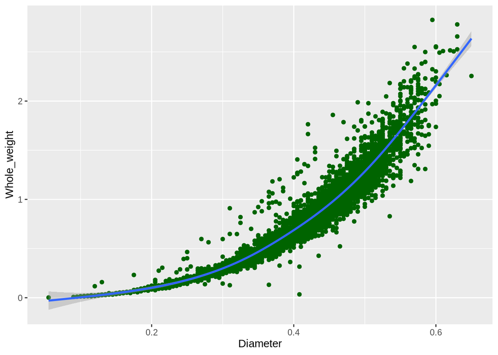

Судя по графику видим, что явно присутствует зависимость. Необходимо проверить на нормальность, чтобы выбрать какой коэффициент корреляции будем использовать.

```r
shapiro.test(data$Diameter)
```

```
##
##  Shapiro-Wilk normality test
##
## data:  data$Diameter
## W = 0.97065, p-value < 2.2e-16
```

```r
shapiro.test(data$Whole_weight)
```

```
##
##  Shapiro-Wilk normality test
##
## data:  data$Whole_weight
## W = 0.97226, p-value < 2.2e-16
```

Значения p-value для обоих переменных сильно меньше 0.05, что позволяет отклонить нулевую гипотезу о нормальности распределения. Так как распределение не нормальное используем коэффициент корреляции Спирмана.

```r
cor(data$Diameter, data$Whole_weight, method = "spearman")
```

```
## [1] 0.9706347
```

Коэффициент корреляции Спирмана примерно равен 1, что говорит о сильной положительной корреляции между двумя этими признаками.

Конец.